# Recommendation Systems for Amazon Books

```python
# !pip install -q scikit-surprise
```

## **Overview:**

In this project, you will build recommemder systems using different approaches.

We will be using the Amazon Review data: https://nijianmo.github.io/amazon/index.html

Note this is a fairly large dataset. We will use the Book review from `"Small" subsets for experimentation` and use `ratings only(51,311,621 ratings)` dataset, which is listed at the last section of the document. However you are required to read through the entire document before proceeding.

This is a fairely large dataset, even though we reduced the data size at various stage, you should write your program with computational cost (both spatial and temporal) in mind. 5% of grades go to efficiency in programing.

- In general when you want to discard a python object when you no longer need it (automatical garbage collection will do it also but probably not in time):

```
del some_data_frame
```

- In general a vectorized function runs much efficiently than `for loop`:

```
    # slow:
    total =0
    for data in dataframe["grades"]:
        if data>5: total+=data
    print(total)
```

```
    # much faster:
    print(
        dataframe["grades"][dataframe["grades"]>5].sum()
)
```

## Task one: Data ingest (10pts)

Please download the dataset first. If you expect you are going to work on this dataset for a period of several days (which is expected), you can mount on your google drive by clicking the folder icon then Google drive icon (the third one on top after clicking the folder icon) from left menu of colab, your drive will be mounted as "/content/drive/MyDrive". Now you can use linux copy command (reference cheatsheet or search for it) to copy the file to your drive. Next time you can just copy it back when you start a new colab session. This dataset contains book reviews from Amazon, with below columns:

- User ID
- Book ID
- Rating (1 to 5)
- Date they gave the ratings(unix timestamp, google for how to convert to datetime object. For validation, 1123804800 should be converted to 2005-08-12 00:00:00)

Because of the large data size, you want to create a small dataset using first 10,000 lines (reference the spark/docker tutorial and project guide for doing this), and play with this file until your code runs ok, then you switch to the full size dataset. Let's assume the small dataset is `books10m.csv`

```python
import pandas as pd
import gc
from datetime import datetime
import numpy as np
import seaborn as sns
import matplotlib.pyplot as plt
import pickle
import os
import sqlite3
from scipy.sparse import csr_matrix
from surprise import SVD
from surprise import Dataset
from surprise.model_selection import cross_validate
from surprise import Reader

import warnings
from surprise import accuracy
from surprise.model_selection import KFold
import pickle
import io
import random
import gc

os.chdir(r"D:\MyDrive2\pythonprojects\class2\DataMining\homework\final_project")
```

```python
df_book = pd.read_csv(r"E:\PythonProjects\datamining\final_project\data\books.csv")
```

```python
df_book = df_book.rename(columns={
    df_book.columns[0]: "user_id",
    df_book.columns[1]: "book_id",
    df_book.columns[2]: "rating",
    df_book.columns[3]: "date"
})
```

```python
df_book['date'] = pd.to_datetime(df_book['date'], unit='s')
```

```python
df_book.head()
```

|  | user_id | book_id | rating | date |
| --- | --- | --- | --- | --- |
| 0 | 0001713353 | A1REUF3A1YCPHM | 5.0 | 2005-03-30 |
| 1 | 0001713353 | A1YRBRK2XM5D5 | 5.0 | 2004-04-04 |
| 2 | 0001713353 | A1V8ZR5P78P4ZU | 5.0 | 2004-02-21 |
| 3 | 0001713353 | A2ZB06582NXCIV | 5.0 | 2016-10-03 |
| 4 | 0001713353 | ACPQVNRD3Z09X | 5.0 | 2016-07-29 |

```python
df_book.iloc[0, :]
```

```
user_id             0001713353
book_id         A1REUF3A1YCPHM
rating                     5.0
date       2005-03-30 00:00:00
Name: 0, dtype: object
```

```python
df_book.dtypes, df_book.shape
```

```
(user_id            object
 book_id            object
 rating            float64
 date       datetime64[ns]
 dtype: object,
 (51311620, 4))
```

### Tried several ways to load the whole json file into memory.

```python
# import gzip
# import shutil
#
# # Path to your .gz file
# input_path = r"E:\PythonProjects\datamining\final_project\data\Books_5.json.gz"
# # Path for the output file (remove .gz extension)
# output_path = r"E:\PythonProjects\datamining\final_project\data\Books_5.json"
#
# with gzip.open(input_path, 'rb') as f_in:
#     with open(output_path, 'wb') as f_out:
#         shutil.copyfileobj(f_in, f_out)
```

```python
# df_rating = pd.read_json(r"E:\PythonProjects\datamining\final_project\data\Books_5.json.gz", compression='gzip',lines=True)
# df_rating = pd.read_json(r"E:\PythonProjects\datamining\final_project\data\Books_5.json", lines=True)
```

```python
# import json
# import pprint
#
# with open(r"E:\PythonProjects\datamining\final_project\data\Books_5.json", 'r', encoding="utf-8",errors="ignore") as f:
#     lines = f.readlines()
#     print(f"Total lines: {len(lines)}")
#     for line in lines:
#         print(line)
#         jline = json.loads(line)
#         pprint.pprint(jline)
#         break
```

```python
# chunks = []
# chunksize = 100000  # Adjust based on your available memory
# for chunk in pd.read_json(r"E:\PythonProjects\datamining\final_project\data\Books_5.json",
#                          lines=True,
#                          chunksize=chunksize):
#     chunks.append(chunk)
#
# df_rating = pd.concat(chunks, ignore_index=True)
```

```python
# import numpy as np
# from scipy.sparse import csr_matrix
# import pandas as pd
#
# # Read the JSON data in chunks to handle large file size
# chunks = []
# chunksize = 100000
# for chunk in pd.read_json(r"E:\PythonProjects\datamining\final_project\data\Books_5.json",
#                          lines=True,
#                          chunksize=chunksize):
#     chunks.append(chunk)
#
# # Combine all chunks into one dataframe
# df_rating = pd.concat(chunks, ignore_index=True)
#
# # Create user and item mappings to convert IDs to indices
# unique_users = df_rating['reviewerID'].unique()
# unique_books = df_rating['asin'].unique()
# user_to_idx = {user: idx for idx, user in enumerate(unique_users)}
# book_to_idx = {book: idx for idx, book in enumerate(unique_books)}
#
# # Convert user and item IDs to indices
# user_indices = [user_to_idx[user] for user in df_rating['reviewerID']]
# book_indices = [book_to_idx[book] for book in df_rating['asin']]
# ratings = df_rating['overall'].values
#
# # Create the sparse CSR matrix
# rating_matrix = csr_matrix((ratings, (user_indices, book_indices)),
#                           shape=(len(unique_users), len(unique_books)))
```

## Task Two: Reservoir Sampling (this involves some algorithms we have not covered, if feeling confused you can temporarily skip this step before the relevant lecture) (15pts)

Write a function `Reservoir_Sampling`:

```
def Reservoir_Sampling(infile_name, outfile_name, k):
    # your code
```

It takes the input file name `infile_name`, which in this case is "Books.csv" that you downloaded and sample k lines. We use the input file to mimic streaming data by read it line by line: you want to uniformly sample from the streaming data which is effectively infinitely long, you want to make sure that at any moment, for the `n` data points you received so far, you keep `k` points that are uniformly sampled from these `n` points. Note `n` is growing over time and is endlessly growing.

We will be implementing an algorithm called Reservoir Sampling to do this, which

- if `n<=k` we keep all incoming data points from the stream in a list `KEEP`;
- when a new data point that is $n^{th}$ comes, if n>k, roll a dice that gives the new data point a probability of **k/n** to be appended to `KEEP`;
  - if the $n^{th}$ new data point is to be added to `KEEP` and if doing so would cause `len(KEEP)==k+1`, we roll another dice to randomly pick a point from `KEEP` (before appending) to throw away, each data point in `KEEP` has equal probability to be discarded.

The idea is to read the input file line by line and use "Reservoir Sampling" algorithm to keep `K` lines. When all lines from the input file is processed, write the `KEEP` to output file `outfile_name`. You will be building recommender system using this randomly sampled file.

This project asks k=10,000,000 (10million, you can use a smaller number before submission):

Following code should create the sampled file `books10m.csv' with 10m lines.

```
Reservoir_Sampling('Books.csv', 'books10m.csv', 10000000)
```

If you don't know how to read text file line by line, consult python cheatsheet or search for it.

```python
# Reset IPython history
# %reset -f


def Reservoir_Sampling(infile_name, outfile_name, k):
    # Increase default buffer size for better performance with large files
    buffer_size = 8 * 1024 * 1024  # 8MB buffer

    with io.open(infile_name, 'rb', buffering=buffer_size) as infile, \
            io.open(outfile_name, 'wb', buffering=buffer_size) as outfile:

        KEEP = []  # Reservoir storage
        n = 0  # Counter for total lines processed

        # Process input file line by line
        for line in infile:
            n += 1

            if n <= k:
                # Fill reservoir until k elements
                KEEP.append(line)
            else:
                # For nth element, pick it with probability k/n
                j = random.randint(0, n - 1)
                if j < k:
                    KEEP[j] = line

        # Write all kept lines to output file
        outfile.writelines(KEEP)
```

### Run code below after your function is done

You should be able to generate a new file 'books10m.csv' after running code below, it samples from "Books.csv" and has 10million lines.

```python
# DO NOT MODIFY THIS CELL
Reservoir_Sampling(r'E:\PythonProjects\datamining\final_project\data\Books.csv',
                   r'E:\PythonProjects\datamining\final_project\data\books10m.csv', 10000000)
```

```python
# Save a even more smaller file books10k.csv for quick test
Reservoir_Sampling(r'E:\PythonProjects\datamining\final_project\data\Books.csv',
                   r'E:\PythonProjects\datamining\final_project\data\books10k.csv', 10000)
```

```python
df_book = pd.read_csv(r"E:\PythonProjects\datamining\final_project\data\books10m.csv", usecols=[0, 1, 2, 3])
df_book = df_book.rename(columns={
    df_book.columns[0]: "user_id",
    df_book.columns[1]: "book_id",
    df_book.columns[2]: "rating",
    df_book.columns[3]: "date"
})
df_book['date'] = pd.to_datetime(df_book['date'], unit='s')
df_book.shape
```

```
(9999999, 4)
```

## Task Three: Data Exploration (15pts)

Please explore your data with appropriate plots and tables/printouts: total counts, value/counts distributions of user-item interactions, time dependency of the statistics etc. (anything related to a good insight into the data and helpful for the predictions)

```python
df_book
```

|  | user_id | book_id | rating | date |
| --- | --- | --- | --- | --- |
| 0 | 0804138656 | A5SPCIGNLRUH9 | 5.0 | 2015-05-23 |
| 1 | 1477830138 | A39CRGVP6S5IGR | 5.0 | 2015-09-15 |
| 2 | 0932194540 | A2C13HP7R5RIJ9 | 5.0 | 2010-12-21 |
| 3 | 038531972X | A34VFF6N5QMPUC | 5.0 | 2018-01-11 |
| 4 | 0553807404 | A79SSJPXFXUH3 | 5.0 | 2014-07-02 |
| ... | ... | ... | ... | ... |
| 9999994 | 193590437X | A2ZIT1GZZR980D | 5.0 | 2012-10-29 |
| 9999995 | 0800721225 | AO6NHS4MBHSZ9 | 2.0 | 2013-01-20 |
| 9999996 | 1456337688 | A2UTBYYF2SJFXN | 5.0 | 2011-03-17 |
| 9999997 | 1975926773 | ADQFI9RB4T1VL | 5.0 | 2018-03-25 |
| 9999998 | 1593639589 | A3MW3GO7LPQ39J | 5.0 | 2014-07-22 |

9999999 rows × 4 columns

```python
# Your code
total_rating_number = len(df_book)
total_user_number = len(df_book.user_id.unique())
total_book_number = len(df_book.book_id.unique())
global_average_rating = df_book.rating.mean()
user_average_rating = df_book.groupby('user_id').mean('rating')
book_average_rating = df_book.groupby('book_id').mean('rating')
matrix_density = total_rating_number / (total_user_number * total_book_number)
```

```python
print(f"Total Rating Number: {total_rating_number}")
print(f"Total User Number: {total_user_number}")
print(f"Total Book Number: {total_book_number}")
print(f"Global Average Rating: {global_average_rating:.2f}")
print(f"Matrix Density: {matrix_density:.4%}")
```

```
Total Rating Number: 9999999
Total User Number: 1588262
Total Book Number: 5345280
Global Average Rating: 4.39
Matrix Density: 0.0001%
```

```python
df_book.rating.value_counts()
```

```
rating
5.0    6620794
4.0    1863196
3.0     747807
1.0     406772
2.0     361429
0.0          1
Name: count, dtype: int64
```

```python
df_book.date.describe()
```

```
count                          9999999
mean     2014-04-29 17:11:00.764587264
min                1996-05-31 00:00:00
25%                2013-05-19 00:00:00
50%                2015-02-12 00:00:00
75%                2016-08-25 00:00:00
max                2018-10-01 00:00:00
Name: date, dtype: object
```

```python
df_book['year'] = df_book['date'].dt.year
years = sorted(df_book['year'].unique())
```

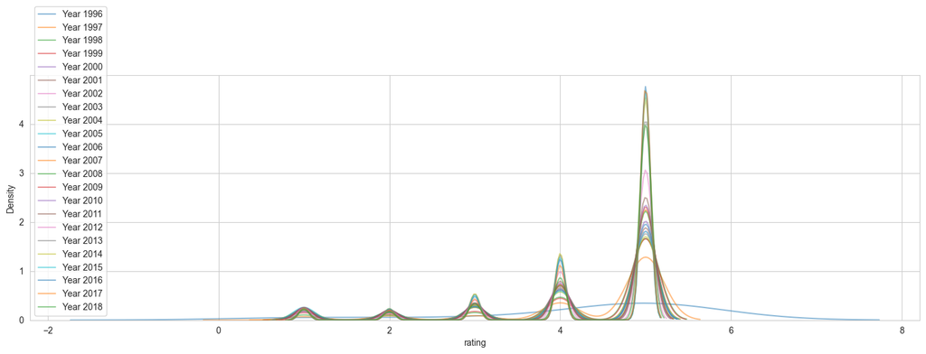

```python
plt.figure(figsize=(18, 5))
for idx, year in enumerate(years):
    year_data = df_book[df_book['year'] == year]['rating']

    # Create KDE plot for each year with offset
    sns.kdeplot(data=year_data,
                fill=False,
                alpha=0.5,
                linewidth=1.5,
                bw_adjust=1,
                label=f'Year {year}')
plt.legend()
```

## Task Four: Triming your data (15pts)

Since the dataset is pretty sparse. Please trim down the size of the data by:

- removing data before '2010-01-01 00:00:00'←, let's focus on more recent data
- removing books that received less than or equal to 2 user ratings
- removing users that reviewed less than or equal to `m` books, where m is 80% quantile of user ratings count (i.e., variable to consider for quantile is the total count of ratings by each user) -- we keep only the top 20% user who are active in rating books.

**Combine** the above steps into a function `trim(book_data_frame)` which takes an arguement of input dataframe and returns trimed dataframe

Call `trim()` to trim your dataset.

Print out the statistics before and after triming for the total users and books and dataframe shape.

```python
# filter by time
df_book = df_book[df_book['date'] > '2010-01-01 00:00:00']
df_book.shape
```

```
(8959639, 5)
```

```python
#filter by rate count
df_book_cnt = df_book.groupby('book_id')['rating'].count()
df_book_cnt = df_book_cnt[df_book_cnt > 2]
df_book_cnt.shape
```

```
(644976,)
```

```python
#filter by user rate count
df_user_cnt = df_book.groupby('user_id')['rating'].count()
df_user_cnt = df_user_cnt.sort_values(ascending=False)[:int(len(df_user_cnt) * 0.2)]
df_user_cnt.shape
```

```
(280940,)
```

```python
def trim(book_data_frame: pd.DataFrame) -> pd.DataFrame:
    # filter by time
    # df_book.iloc[0,:]['date'].timestamp()
    # dt = datetime.strptime('2010-01-01 00:00:00', '%Y-%m-%d %H:%M:%S')
    # timestamp = int(dt.timestamp())
    # print(timestamp)
    # df_date = book_data_frame[book_data_frame['date'].apply(lambda x: x.timestamp()) > timestamp]
    df_date = book_data_frame[book_data_frame['date'] > '2010-01-01 00:00:00']

    #filter by rate count
    df_book_cnt = df_date.groupby('book_id')['rating'].count()
    df_book_cnt = df_book_cnt[df_book_cnt > 2]

    #filter by user rate count
    df_user_cnt = df_date.groupby('user_id')['rating'].count()
    df_user_cnt = df_user_cnt.sort_values(ascending=False)[:int(len(df_user_cnt) * 0.2)]

    result = book_data_frame[book_data_frame['user_id'].isin(df_user_cnt.index)]
    result = result[result['book_id'].isin(df_book_cnt.index)]
    return result
```

```python
df_book = trim(df_book)
```

```python
total_rating_number = len(df_book)
total_user_number = len(df_book.user_id.unique())
total_book_number = len(df_book.book_id.unique())
global_average_rating = df_book.rating.mean()
user_average_rating = df_book.groupby('user_id').mean('rating')
book_average_rating = df_book.groupby('book_id').mean('rating')
matrix_density = total_rating_number / (total_user_number * total_book_number)
```

```python
print(f"Total Rating Number: {total_rating_number}")
print(f"Total User Number: {total_user_number}")
print(f"Total Book Number: {total_book_number}")
print(f"Global Average Rating: {global_average_rating:.2f}")
print(f"Matrix Density: {matrix_density:.4%}")
```

```
Total Rating Number: 3288353
Total User Number: 268132
Total Book Number: 629094
Global Average Rating: 4.39
Matrix Density: 0.0019%
```

```python
# Save the checkpoint
# Comment to avoid overwriting
# pickle.dump(df_book, open(r"E:\PythonProjects\datamining\final_project\data\book_trimed.pkl", "wb"))
```

## Task Five: fit the model using the data. (20pts)

You should prepare your data for surprise library. Check document [here](https://surprise.readthedocs.io/en/stable/getting_started.html#use-a-custom-dataset) for how to read data from pandas data frame or from text file--you need to make sure your data frame or text file follow the required format as shown in the example code.

Read documentation for parameters in `SVD()`: https://surprise.readthedocs.io/en/stable/matrix_factorization.html?highlight=lr_bu#surprise.prediction_algorithms.matrix_factorization.SVD.bu

- You should run the code with default call to `SVD()`, as well as with `n_factors=50, and 150)`, and **combined** with `lr_all=.01 and 0.1`; `reg_all=.01, 0.1` (make sure you understand what these parameter mean, get a better understanding by relating these to equations in the lecture slides), **respectively**.
- Compare both the **RMSE** and **running time** for **each case.**
- Missing any of boldfaced requirement causes point deduction

```python
SVD().lr_bu
```

```
0.005
```

```python
# Your code to prepare data


# Load the dataset
with open(r"E:\PythonProjects\datamining\final_project\data\book_trimed.pkl", 'rb') as file:
    data = pickle.load(file)
data.shape
```

```
(3290537, 5)
```

```python
data.rating.value_counts()
```

```
rating
5.0    2065271
4.0     739742
3.0     288198
2.0     112775
1.0      84550
0.0          1
Name: count, dtype: int64
```

```python
data = data[data['rating'] > 0]
```

```python
reader = Reader(rating_scale=(1, 5))  # Adjust rating scale as needed
data_set = Dataset.load_from_df(data[['user_id', 'book_id', 'rating']], reader)
```

#### Run code chunk below as is after data is loaded.

```python
# define a cross-validation iterator
kf = KFold(n_splits=3)
```

```python
algo = SVD()
for trainset, testset in kf.split(data_set):
    # train and test algorithm.
    algo.fit(trainset)
    predictions = algo.test(testset)

    # Compute and print Root Mean Squared Error
    accuracy.rmse(predictions, verbose=True)
```

```
RMSE: 0.8878
RMSE: 0.8886
RMSE: 0.8900
```

Output example (yours may look differently):

```
RMSE: 0.8948
RMSE: 0.8936
RMSE: 0.8968
```

#### Copy code chunk above and use different parameters for `SVD` call, then rerun.

```python
# your code `n_factors=50, and 150)`, and **combined** with `lr_all=.01 and 0.1`;  `reg_all=.01, 0.1`
import time

lr_all = [0.01, 0.1]
reg_all = [0.01, 0.1]
n_factors = [50, 150]


def format_time(seconds):
    minutes = seconds // 60
    seconds = seconds % 60
    return f"{int(minutes)}m {seconds:.2f}s"


df_rmse = pd.DataFrame(columns=['lr_all', 'reg_all', 'n_factor', 'time', 'rmse'])

for lr in lr_all:
    for reg in reg_all:
        for n_factor in n_factors:
            algo = SVD(n_factors=n_factor, lr_all=lr, reg_all=reg)

            rmses = []
            start_time = time.time()
            for trainset, testset in kf.split(data_set):
                # train and test algorithm.
                algo.fit(trainset)
                predictions = algo.test(testset)

                # Compute and print Root Mean Squared Error
                print(f"lr_all:{lr}, reg_all:{reg}, n_factor:{n_factor}")
                rmse = accuracy.rmse(predictions, verbose=True)
                print(f"RMSE: {rmse:.4f}")
                rmses.append(rmse)

            end_time = time.time()
            fold_time = end_time - start_time
            mean_rmse = np.mean(rmses)
            row = pd.DataFrame(
                {'lr_all': [lr], 'reg_all': [reg], 'n_factor': [n_factor], 'time': [fold_time], 'rmse': [mean_rmse]})
            df_rmse = pd.concat([df_rmse, row], ignore_index=True)
```

```
lr_all:0.01, reg_all:0.01, n_factor:50
RMSE: 0.8838
RMSE: 0.8838
lr_all:0.01, reg_all:0.01, n_factor:50
RMSE: 0.8840
RMSE: 0.8840
lr_all:0.01, reg_all:0.01, n_factor:50
RMSE: 0.8858
RMSE: 0.8858
```

```
lr_all:0.01, reg_all:0.01, n_factor:150
RMSE: 0.8925
RMSE: 0.8925
lr_all:0.01, reg_all:0.01, n_factor:150
RMSE: 0.8924
RMSE: 0.8924
lr_all:0.01, reg_all:0.01, n_factor:150
RMSE: 0.8931
RMSE: 0.8931
lr_all:0.01, reg_all:0.1, n_factor:50
RMSE: 0.8755
RMSE: 0.8755
lr_all:0.01, reg_all:0.1, n_factor:50
RMSE: 0.8767
RMSE: 0.8767
lr_all:0.01, reg_all:0.1, n_factor:50
RMSE: 0.8773
RMSE: 0.8773
lr_all:0.01, reg_all:0.1, n_factor:150
RMSE: 0.8803
RMSE: 0.8803
lr_all:0.01, reg_all:0.1, n_factor:150
RMSE: 0.8810
RMSE: 0.8810
lr_all:0.01, reg_all:0.1, n_factor:150
RMSE: 0.8807
RMSE: 0.8807
lr_all:0.1, reg_all:0.01, n_factor:50
RMSE: 0.8982
RMSE: 0.8982
lr_all:0.1, reg_all:0.01, n_factor:50
RMSE: 0.8988
RMSE: 0.8988
lr_all:0.1, reg_all:0.01, n_factor:50
RMSE: 0.8996
RMSE: 0.8996
lr_all:0.1, reg_all:0.01, n_factor:150
RMSE: 0.8861
RMSE: 0.8861
lr_all:0.1, reg_all:0.01, n_factor:150
```

[output cut: 8 more lines]

```
lr_all:0.1, reg_all:0.1, n_factor:50
RMSE: 0.8922
RMSE: 0.8922
lr_all:0.1, reg_all:0.1, n_factor:50
RMSE: 0.8927
RMSE: 0.8927
lr_all:0.1, reg_all:0.1, n_factor:150
RMSE: 0.8827
RMSE: 0.8827
lr_all:0.1, reg_all:0.1, n_factor:150
RMSE: 0.8824
RMSE: 0.8824
lr_all:0.1, reg_all:0.1, n_factor:150
RMSE: 0.8825
RMSE: 0.8825
```

```python
# I stored the result in a sqlite db

df_rmse = pd.read_sql("SELECT * FROM rmse", sqlite3.connect("usr_rcs.sqlite"))
```

```python
df_rmse
```

|  | lr_all | reg_all | n_factor | time | rmse |
| --- | --- | --- | --- | --- | --- |
| 0 | 0.01 | 0.01 | 50 | 111.410039 | 0.884048 |
| 1 | 0.01 | 0.01 | 150 | 135.617260 | 0.892240 |
| 2 | 0.01 | 0.10 | 50 | 109.017855 | 0.876004 |
| 3 | 0.01 | 0.10 | 150 | 138.573165 | 0.880057 |
| 4 | 0.10 | 0.01 | 50 | 109.442813 | 0.899201 |
| 5 | 0.10 | 0.01 | 150 | 138.581531 | 0.885470 |
| 6 | 0.10 | 0.10 | 50 | 110.087006 | 0.891641 |
| 7 | 0.10 | 0.10 | 150 | 137.073136 | 0.881697 |

# Visualization in chrome browser

```python
import plotly.express as px
import plotly.io as pio

pio.renderers.default = "browser"
```

```python
# Create interactive 3D scatter plot
fig = px.scatter_3d(
    df_rmse,
    x='reg_all',
    y='n_factor',
    z='rmse',
    color='lr_all',
    title='rmse vs reg_all vs n_factor',
    labels={
        'reg_all': 'reg_all',
        'n_factor': 'n_factor',
        'rmse': 'rmse',
        'lr_all': 'Learning Rate'
    },
    color_discrete_sequence=px.colors.qualitative.Set1,  # Use a discrete color palette
    hover_data={
        'rmse': ':.4f',  # Format RMSE to 4 decimal places
        'reg_all': True,
        'n_factor': True
    },
    # Custom hover template
    hover_name=None,
    opacity=0.6

)

# Update layout for better visualization
fig.update_layout(
    scene=dict(
        xaxis_title='reg_all',
        yaxis_title='n_factor',
        zaxis_title='rmse'
    ),
    width=900,
    height=700,
    margin=dict(l=0, r=0, b=0, t=30)
)

fig.update_traces(
    hovertemplate="<br>".join([
        "RMSE: %{z:.4f}",
        "Regularization: %{x}",
        "n_factor: %{y}",
    ])
)

# Show the plot
fig.show()
```

## Task Six: use the model for recommendation (15pts)

Use any one of the users from above trainset in the last code chunk (n_factors=150) to predict his/her book ratings. Print the top 10 books that he did not rate but would rate highest as recommended books.

You can reference document here: https://surprise.readthedocs.io/en/stable/getting_started.html#train-on-a-whole-trainset-and-the-predict-method

Read the example code about how to do this. Please note for prediction syntax it doesn't matter if

```
algo = KNNBasic()
```

or

```
algo = SVD()
```

The syntax for prediction is the same.

## rec top 10 books for uid

```python
def get_top_10_book(uid: str = "0373244045"):
    book_list = data.book_id.unique()
    # The book this user commented
    user_book = data[data['user_id'] == uid]['book_id'].unique()
    # The book not commented by this user
    user_not_book = [i for i in book_list if not i in user_book]
    # Predict the rating for the books note rated by this user
    user_not_book_rate = [algo.predict(uid, i)[3] for i in user_not_book]
    # Sort the book index by rating in descending order, get the top 10
    top_n_book = np.argsort(user_not_book_rate)[::-1][:10]
    # Get the book names by sorted index top 10
    selected_books = [user_not_book[i] for i in list(top_n_book)]
    return selected_books
```

```python
get_top_10_book('1500336513')
```

```
['A287QJTE1HFZZ5',
 'A15Y0XJPEGJYTK',
 'A6R7UMU1J68XQ',
 'A2MOAH15GI79HF',
 'ATZESZ8SZOWDF',
 'APBOM5Z9PHPUH',
 'AIR269ZFK02P8',
 'A3HEPG2AS0YG6Z',
 'A5UT8WKIJILKA',
 'A1KF55C7XRPSC9']
```

```python
data
```

|  | user_id | book_id | rating | date | year |
| --- | --- | --- | --- | --- | --- |
| 5 | 0001713353 | AVP0HXC9FG790 | 5.0 | 2016-06-20 | 2016 |
| 11 | 0001713353 | A2RE7WG349NV5D | 5.0 | 2015-07-09 | 2015 |
| 15 | 1451693494 | A3518R1F46NWOM | 5.0 | 2014-08-19 | 2014 |
| 21 | 1502830825 | A1FW6L02VSCUYH | 5.0 | 2015-01-04 | 2015 |
| 23 | 0001713353 | A3M314LI9OYME | 5.0 | 2013-10-08 | 2013 |
| ... | ... | ... | ... | ... | ... |
| 9999984 | 0553393235 | A2L0GFTTI618RU | 5.0 | 2013-10-05 | 2013 |
| 9999987 | 042526257X | AZTFBJTENKT1T | 5.0 | 2015-11-24 | 2015 |
| 9999994 | 1478227133 | A2USTMJDOQPOA2 | 3.0 | 2014-09-22 | 2014 |
| 9999995 | 1490914943 | AGE28EEF9PE6U | 5.0 | 2014-06-08 | 2014 |
| 9999998 | 1500165972 | A1TNVUMSPY8BM1 | 4.0 | 2014-06-10 | 2014 |

3290536 rows × 5 columns

## Task Seven: build the SVD from scratch. (20pts, including 10pts as bonus)

Reference article [here](https://albertauyeung.github.io/2017/04/23/python-matrix-factorization.html) and notebook [here](https://albertauyeung.github.io/2017/04/23/python-matrix-factorization.html) for doing SVD/matrix factorization from scratch without using surprise. You can copy his code but you must use our reservoir sampled data from Books.csv, and you can further reduce the data size to be 10% of the rows to speed up computation.

You want to play with his code first and after you understand it you put in our dataset.

You can use the train/test split function from surprise to do train/test split:

```
from surprise.model_selection import train_test_split
trainset, testset = train_test_split(data, test_size=.25)

# train your copied model with our data
```

Important Note:

- This is a fairely large dataset. In order to avoid crashing due to memory blowing up, some students in the past resampled the total row number of the ratings to 3489820. This is fine if you do not care about bonus points. For full bonus points, You are allowed to randomly resample at least 30% of the rows after Task Four and then trim again to discard books that receive equal to or less than 2 user ratings (after 30% resampling, some books will lose some user ratings and become `rare` books again). Trick for memory problems: you want to compute how many GB used by P and Q, when K is, say 200. Thoaw RE TWO largest memomery chunks in the project if you properly program it. Please compute what if you directly create utility matrix (so you know why you should avoid it at any stage of the project). In Colab available memory is ~ 10GB. Set numpy `dtype` to "float32" (each float takes 4 bytes) will save half of memory usage than default "double"/"float64"
- In addition, you must use sparse matrix representation to represent the utility matrix to void crashing (refer to previous lab and documentation for `csr_matrix` in `scipy.sparse`).
- You have to figure out how to convert trainset and testset objects into the data format for the MF object. You can use python's `dir()` function to see methods/attributes of trainset, testset to explore, and the best way is to read `suprise` documentation.
- Then you call the `get_rating` method in `MF` class to predict ratings from testset, then you compute RMSE using the ratings from testset as ground truth.

```python
class MF():

    def __init__(self, R, K, alpha, beta, iterations):
        """
        Perform matrix factorization to predict empty
        entries in a matrix.

        Arguments
        - R (ndarray)   : user-item rating matrix
        - K (int)       : number of latent dimensions
        - alpha (float) : learning rate
        - beta (float)  : regularization parameter
        """

        self.R = R
        self.num_users, self.num_items = R.shape
        self.K = K
        self.alpha = alpha
        self.beta = beta
        self.iterations = iterations

    def train(self):
        # Initialize user and item latent feature matrice
        self.P = np.random.normal(scale=1. / self.K, size=(self.num_users, self.K))
        self.Q = np.random.normal(scale=1. / self.K, size=(self.num_items, self.K))

        # Initialize the biases
        self.b_u = np.zeros(self.num_users)
        self.b_i = np.zeros(self.num_items)
        self.b = np.mean(self.R[np.where(self.R != 0)])

        # Create a list of training samples
        self.samples = [
            (i, j, self.R[i, j])
            for i in range(self.num_users)
            for j in range(self.num_items)
            if self.R[i, j] > 0
        ]

        # Perform stochastic gradient descent for number of iterations
        training_process = []
        for i in range(self.iterations):
            np.random.shuffle(self.samples)
            self.sgd()
            mse = self.mse()
            training_process.append((i, mse))
            if (i + 1) % 10 == 0:
                print("Iteration: %d ; error = %.4f" % (i + 1, mse))

        return training_process

    def mse(self):
        """
        A function to compute the total mean square error
        """
        xs, ys = self.R.nonzero()
        predicted = self.full_matrix()
        error = 0
        for x, y in zip(xs, ys):
            error += pow(self.R[x, y] - predicted[x, y], 2)
        return np.sqrt(error)

    def sgd(self):
        """
        Perform stochastic graident descent
        """
        for i, j, r in self.samples:
            # Computer prediction and error
            prediction = self.get_rating(i, j)
            e = (r - prediction)

            # Update biases
            self.b_u[i] += self.alpha * (e - self.beta * self.b_u[i])
            self.b_i[j] += self.alpha * (e - self.beta * self.b_i[j])

            # Update user and item latent feature matrices
            self.P[i, :] += self.alpha * (e * self.Q[j, :] - self.beta * self.P[i, :])
            self.Q[j, :] += self.alpha * (e * self.P[i, :] - self.beta * self.Q[j, :])

    def get_rating(self, i, j):
        """
        Get the predicted rating of user i and item j
        """
        prediction = self.b + self.b_u[i] + self.b_i[j] + self.P[i, :].dot(self.Q[j, :].T)
        return prediction

    def full_matrix(self):
        """
        Computer the full matrix using the resultant biases, P and Q
        """
        return self.b + self.b_u[:, np.newaxis] + self.b_i[np.newaxis:, ] + self.P.dot(self.Q.T)
```

```python
R = np.array([
    [5, 3, 0, 1],
    [4, 0, 0, 1],
    [1, 1, 0, 5],
    [1, 0, 0, 4],
    [0, 1, 5, 4],
])

mf = MF(R, K=2, alpha=0.1, beta=0.01, iterations=20)
```

```python
mf.train()
mf.get_rating(2, 3)
mf.mse()
mf.full_matrix()
```

```
Iteration: 10 ; error = 0.3487
Iteration: 20 ; error = 0.0627
```

```
array([[4.97741296, 3.01432575, 2.15464326, 1.00159637],
       [4.00816112, 2.56530194, 1.91469885, 1.01899245],
       [1.01628937, 0.98161098, 5.84116035, 4.98098285],
       [0.99735811, 1.03013045, 4.63620617, 3.9806118 ],
       [1.47363508, 1.02646674, 4.97501264, 4.01042782]])
```

### Load data

```python
def count_lines(file_path):
    with open(file_path, 'r') as f:
        count = sum(1 for _ in f)
    return count


def print_first_lines(file_path):
    with open(file_path, 'r') as f:
        print(f.readline())


# Use the function
file_path = r"E:\PythonProjects\datamining\final_project\data\books10m.csv"
print_first_lines(file_path)
total_lines = count_lines(file_path)
print(f"Total number of lines: {total_lines}")
```

```
0001713353,A1C6M8LCIX4M6M,5.0,1123804800

Total number of lines: 10000000
```

### Commencement of official operations

### Load data into CSR matrix, getting the rate, user to index, book to index

```python
import numpy as np
from scipy.sparse import csr_matrix
import csv


def create_csr_from_csv(file_path, chunk_size=1000000):
    # Dictionaries to map user/book IDs to indices
    user_to_idx = {}
    book_to_idx = {}
    current_user_idx = 0
    current_book_idx = 0

    # Lists to store data for CSR matrix
    rows = []
    cols = []
    data = []

    with open(file_path, 'r') as f:
        reader = csv.reader(f)
        # next(reader)  # Skip header if exists

        chunk = []
        for i, line in enumerate(reader):
            user_id, book_id, rating = line[:3]  # Take first 3 columns, 4th is date which is useless for us

            rating = float(rating)

            if rating <= 0:
                continue

            # Map IDs to indices
            if user_id not in user_to_idx:
                user_to_idx[user_id] = current_user_idx
                current_user_idx += 1
            if book_id not in book_to_idx:
                book_to_idx[book_id] = current_book_idx
                current_book_idx += 1

            # Add to current chunk
            rows.append(user_to_idx[user_id])
            cols.append(book_to_idx[book_id])
            data.append(float(rating))

            # Process chunk if size reached
            if len(rows) % chunk_size == 0:
                print(f"Processed {i + 1} rows")

    # Create the final CSR matrix
    rating_matrix = csr_matrix(
        (data, (rows, cols)),
        shape=(len(user_to_idx), len(book_to_idx))
    )

    print(f"Final matrix shape: {rating_matrix.shape}")
    print(f"Number of non-zero entries: {rating_matrix.nnz}")
    print(f"Sparsity: {rating_matrix.nnz / (rating_matrix.shape[0] * rating_matrix.shape[1]):.4%}")

    return rating_matrix, user_to_idx, book_to_idx


# Use the function
file_path = r"E:\PythonProjects\datamining\final_project\data\books10m.csv"
rating_matrix, user_to_idx, book_to_idx = create_csr_from_csv(file_path)
```

```
Processed 1000000 rows
Processed 2000000 rows
Processed 3000000 rows
Processed 4000000 rows
Processed 5000000 rows
Processed 6000000 rows
Processed 7000000 rows
Processed 8000001 rows
Processed 9000001 rows
Final matrix shape: (1588262, 5345281)
Number of non-zero entries: 9988363
Sparsity: 0.0001%
```

### Dump the rating index, user to index, book to index. For future reference

```python
# Saving the rating_matrix, user_to_idx, book_to_idx to file
rating_matrix_params = {
    'rating_matrix': rating_matrix,
    'user_to_idx': user_to_idx,
    'book_to_idx': book_to_idx
}
with open('rating_matrix_params.pkl', 'wb') as f:
    pickle.dump(rating_matrix_params, f)
```

```python
# Loading the rating_matrix, user_to_idx, book_to_idx from file
with open('rating_matrix_params.pkl', 'rb') as f:
    rating_matrix_params = pickle.load(f)

# Access the variables
rating_matrix = rating_matrix_params['rating_matrix']
user_to_idx = rating_matrix_params['user_to_idx']
book_to_idx = rating_matrix_params['book_to_idx']
```

```python
rating_matrix.data.mean()
```

```
4.3980990678852985
```

### Convert the CSR rating matrix to list of tuples, so that could be easily elevate to GPU

```python
from tqdm import tqdm


def gen_samples(R):
    # Get nonzero indices
    i_indices, j_indices = R.nonzero()
    total = len(i_indices)

    # Create samples list with tqdm progress bar
    samples = [
        (i, j, R[i, j])
        for i, j in tqdm(zip(i_indices, j_indices),
                         total=total,
                         desc="Generating samples")
    ]
    return samples


samples = gen_samples(rating_matrix)
```

### Import torch and confirm the existence of calculation hardware

```python
import torch

print(f"CUDA: {torch.cuda.is_available()}")


# pip3 install torchvision torchaudio --index-url https://download.pytorch.org/whl/cu118
```

```
CUDA: True
```

### Drop the sub-tank and get ready to fight

```python
if ('mfcsr' in locals() or 'mfcsr' in globals()) and mfcsr is not None:
    del mfcsr
if torch.cuda.is_available():
    torch.cuda.empty_cache()
    torch.cuda.reset_max_memory_allocated()
    torch.cuda.reset_max_memory_cached()

gc.collect()
# Check GPU memory usage
print(torch.cuda.memory_allocated())
print(torch.cuda.memory_reserved())
```

```
0
0
```

```python
# First delete any existing tensors/models
if ('mfcsr' in locals() or 'mfcsr' in globals()) and mfcsr is not None:
    del mfcsr

# Clear all PyTorch GPU cached memory
if torch.cuda.is_available():
    # Delete all references to tensors and models
    for obj in gc.get_objects():
        try:
            if torch.is_tensor(obj):
                if obj.is_cuda:
                    del obj
            elif hasattr(obj, 'cuda'):
                if hasattr(obj, 'is_cuda'):
                    if obj.is_cuda:
                        del obj
        except Exception as e:
            pass

    # Empty cache
    torch.cuda.empty_cache()
    # Reset peak stats
    torch.cuda.reset_peak_memory_stats()
    torch.cuda.reset_max_memory_allocated()
    torch.cuda.reset_max_memory_cached()

# Force garbage collection multiple times
for _ in range(2):
    gc.collect()

# Check memory status
print(f"Allocated: {torch.cuda.memory_allocated() / 1024 ** 2:.2f} MB")
print(f"Reserved: {torch.cuda.memory_reserved() / 1024 ** 2:.2f} MB")
```

```
Allocated: 0.00 MB
Reserved: 0.00 MB
```

### Prototyping the battleship

```python
# from tqdm import tqdm
# import numpy as np
# import torch


class MF_csr_gpu():
    """
    Matrix Factorization class optimized for CSR matrix format with numerical stability improvements.

    Uses float64 precision and includes safeguards against overflow/underflow conditions.

    Parameters
    ----------
    R : scipy.sparse.csr_matrix
        User-item rating matrix in CSR format
    K : int
        Number of latent dimensions
    alpha : float
        Learning rate (between 0 and 1)
    beta : float
        Regularization parameter
    iterations : int
        Number of iterations for training
    samples : list
        Pre-generated training samples as (user, item, rating) tuples

    Attributes
    ----------
    P : ndarray
        User latent feature matrix
    Q : ndarray
        Item latent feature matrix
    b_u : ndarray
        User biases
    b_i : ndarray
        Item biases
    b : float
        Global bias
    """

    def __init__(self, R, K, alpha, beta, iterations, samples):
        self.R = R
        self.num_users, self.num_items = R.shape
        self.K = K
        self.alpha = np.float64(alpha)
        self.beta = np.float64(beta)
        self.iterations = iterations
        self.samples = samples

        # Numerical bounds for stability
        self.MIN_RATING = 1.0
        self.MAX_RATING = 5.0
        self.EPSILON = np.finfo(np.float64).eps

        # Check if CUDA is available
        self.device = torch.device('cuda' if torch.cuda.is_available() else 'cpu')
        print(self.device)
        torch.cuda.empty_cache()

    def train(self):
        # Initialize matrices with float64 dtype
        rng = np.random.default_rng()
        init_scale = np.sqrt(1.0 / self.K)  # More stable initialization

        self.P = rng.normal(0, init_scale, size=(self.num_users, self.K)).astype(np.float64)
        self.Q = rng.normal(0, init_scale, size=(self.num_items, self.K)).astype(np.float64)

        # Initialize biases with float64
        self.b_u = np.zeros(self.num_users, dtype=np.float64)
        self.b_i = np.zeros(self.num_items, dtype=np.float64)
        self.b = np.float64(self.R.data.mean())

        print(f"Number of training samples: {len(self.samples)}")

        # Move data to GPU
        self.b_u = torch.tensor(self.b_u, dtype=torch.float64, device="cuda")
        self.b_i = torch.tensor(self.b_i, dtype=torch.float64, device="cuda")
        self.P = torch.tensor(self.P, dtype=torch.float64, device="cuda")
        self.Q = torch.tensor(self.Q, dtype=torch.float64, device="cuda")
        self.b = torch.tensor(self.b, dtype=torch.float64, device="cuda")
        training_process = []
        for i in range(self.iterations):
            # print(f"shuffling")
            rng.shuffle(self.samples)
            # print(f"Iteration: {i+1}")
            # print("sgd")
            self.sgd()
            # print("mse")
            mse = self.mse_gpu()
            training_process.append((i, mse))
            print("Iteration: %d ; error = %.4f" % (i + 1, mse))

        return training_process

    def mse_gpu(self):
        # xs, ys = self.R.nonzero()

        squared_error = 0.0
        n_ratings = len(self.samples)

        batch_size = 2000000
        for i in range(0, n_ratings, batch_size):
            # print(f"mse,i:{i}")
            samples = torch.tensor(self.samples[i:i + batch_size], dtype=torch.float64,
                                   device="cuda")
            batch_xs = samples[:, 0]
            batch_ys = samples[:, 1]
            all_acctual_ratings = samples[:, 2]

            P_batch = self.P[batch_xs.long()]
            Q_batch = self.Q[batch_ys.long()]

            # Compute dot products for the batch
            dot_products = torch.sum(P_batch * Q_batch, dim=1)
            predictions = self.b + self.b_u[batch_xs.long()] + self.b_i[batch_ys.long()] + dot_products
            # predictions_gpu = torch.clamp(predictions, self.MIN_RATING, self.MAX_RATING)

            # Calculate squared errors for this batch
            batch_errors = all_acctual_ratings - predictions
            batch_squared_error = torch.sum(batch_errors ** 2).item()

            # Add to total squared error
            squared_error += batch_squared_error

        result = np.sqrt(squared_error / (n_ratings + self.EPSILON))

        return result

    def sgd(self):
        """
        Perform stochastic gradient descent with numerical stability improvements.
        """
        # Move data to GPU
        batch_size = 1000000
        for i in range(0, len(self.samples), batch_size):
            # print(f"sgd,i:{i}")
            samples = torch.tensor(self.samples[i:i + batch_size], dtype=torch.float64,
                                   device="cuda")

            # Unpack i, j, r from samples
            i = samples[:, 0].long()  # Convert to long for indexing
            j = samples[:, 1].long()  # Convert to long for indexing
            r = samples[:, 2]  # Ratings

            # Predictions for all samples
            predictions = (
                    torch.sum(self.P[i] * self.Q[j], dim=1) + self.b_u[i] + self.b_i[j] + self.b
            )

            # Compute errors
            errors = r - predictions

            # Gradient updates for biases
            bu_grad = errors - self.beta * self.b_u[i]
            bi_grad = errors - self.beta * self.b_i[j]

            # Update user and item biases
            self.b_u[i] += self.alpha * torch.clamp(bu_grad, -1e3, 1e3)
            self.b_i[j] += self.alpha * torch.clamp(bi_grad, -1e3, 1e3)

            # Gradient updates for latent factors
            P_grad = errors.unsqueeze(1) * self.Q[j] - self.beta * self.P[i]
            Q_grad = errors.unsqueeze(1) * self.P[i] - self.beta * self.Q[j]

            # Update latent factors
            self.P.index_add_(0, i, self.alpha * torch.clamp(P_grad, -1e3, 1e3))
            self.Q.index_add_(0, j, self.alpha * torch.clamp(Q_grad, -1e3, 1e3))
```

### Focusing on the target

```python
rating_matrix
```

```
<Compressed Sparse Row sparse matrix of dtype 'float64'
	with 9988363 stored elements and shape (1588262, 5345281)>
```

### Instantiation and wrangling with the target

```python
mfcsr = MF_csr_gpu(rating_matrix, K=50, alpha=0.001, beta=0.2, iterations=20, samples=samples)
training_process = mfcsr.train()
```

```
cuda
Number of training samples: 9988363
Iteration: 1 ; error = 1.0936
Iteration: 2 ; error = 1.0882
Iteration: 3 ; error = 1.0828
Iteration: 4 ; error = 1.0766
Iteration: 5 ; error = 1.0690
Iteration: 6 ; error = 1.0587
Iteration: 7 ; error = 1.0466
Iteration: 8 ; error = 1.0368
Iteration: 9 ; error = 1.0311
Iteration: 10 ; error = 1.0269
Iteration: 11 ; error = 1.0229
Iteration: 12 ; error = 1.0190
Iteration: 13 ; error = 1.0152
Iteration: 14 ; error = 1.0114
Iteration: 15 ; error = 1.0077
Iteration: 16 ; error = 1.0041
Iteration: 17 ; error = 1.0005
Iteration: 18 ; error = 0.9969
Iteration: 19 ; error = 0.9934
Iteration: 20 ; error = 0.9900
```

### Scavenge for loot

```python
# Create CPU copies while keeping original CUDA tensors unchanged
b_u_cpu = mfcsr.b_u.cpu().clone()
b_i_cpu = mfcsr.b_i.cpu().clone()
P_cpu = mfcsr.P.cpu().clone()
Q_cpu = mfcsr.Q.cpu().clone()
b_cpu = mfcsr.b.cpu().clone()
```

```python
# Create a dictionary with all the parameters
# Comment to void overwriting

# model_params = {
#     'b_u': b_u_cpu,
#     'b_i': b_i_cpu,
#     'P': P_cpu,
#     'Q': Q_cpu,
#     'b': b_cpu,
#     'training_process': training_process
# }
#
# # Save the parameters to a file
# with open('model_params.pkl', 'wb') as f:
#     pickle.dump(model_params, f)
```

### Reproducing the Intellectual achievements

```python
with open('model_params.pkl', 'rb') as f:
    loaded_params = pickle.load(f)

# Access the variables
b_u_cpu = loaded_params['b_u']
b_i_cpu = loaded_params['b_i']
P_cpu = loaded_params['P']
Q_cpu = loaded_params['Q']
b_cpu = loaded_params['b']
training_process = loaded_params['training_process']
```

### The prophet appears

```python
def predict_cpu(user_id: str, book_id: str):
    """
    Predict rating for given user and item with numerical stability checks.

    Parameters
    ----------
    user_id : str
        User ID
    book_id : str
        book ID

    Returns
    -------
    float
        Predicted rating clipped to valid range
    """

    MIN_RATING = 1.0
    MAX_RATING = 5.0

    uid = user_to_idx.get(user_id, None)
    iid = book_to_idx.get(book_id, None)

    if uid is None or iid is None:
        return -1

    dot_product = np.dot(P_cpu[uid, :], Q_cpu[iid, :])
    prediction = b_cpu + b_u_cpu[uid] + b_i_cpu[iid] + dot_product

    # Clip prediction to valid rating range
    return np.clip(prediction, MIN_RATING, MAX_RATING)
```

### chant a spell

```python
predict_cpu('1939811104', 'AWH493Q118CB7')
```

```
tensor(4.4173, dtype=torch.float64)
```